# Regression project: Assignment group 9

Lars Reiter Nielsen & Anda-Paula Udrea

```r
titanic <- read.csv(
  "http://www.math.ku.dk/~susanne/titanic.txt",
  header = TRUE,
  colClasses = c("factor", "integer","factor", "numeric", "integer", "integer"))
```

```r
summary(titanic)
```

```
##  pclass     survived         sex           age            sibsp
##  1:323   Min.   :0.000   female:466   Min.   : 0.17   Min.   :0.0000
##  2:277   1st Qu.:0.000   male  :843   1st Qu.:21.00   1st Qu.:0.0000
##  3:709   Median :0.000                Median :28.00   Median :0.0000
##          Mean   :0.382                Mean   :29.88   Mean   :0.4989
##          3rd Qu.:1.000                3rd Qu.:39.00   3rd Qu.:1.0000
##          Max.   :1.000                Max.   :80.00   Max.   :8.0000
##                                       NA's   :263
##      parch
##  Min.   :0.000
##  1st Qu.:0.000
##  Median :0.000
##  Mean   :0.385
##  3rd Qu.:0.000
##  Max.   :9.000
##
```

The variables in the data set are:

- **pclass**: Passenger Class (1 = 1st; 2 = 2nd; 3 = 3rd).
- **survived**: Survival (0 = No; 1 = Yes).
- **sex**: Sex.
- **age**: Age.
- **sibsp**: Number of Siblings/Spouses Aboard.
- **parch**: Number of Parents/Children Aboard.

# Exploratory analysis

We notice $263$ missing values of the `age` variable. For all we know, these are **MCAR**, hence unrelated to all the variables. We can safely remove the corresponding observations, but this will be a grand waste of data, so we will attempt to impute the values instead.

For now lets postpone the imputation of the missing values, and plot the data:

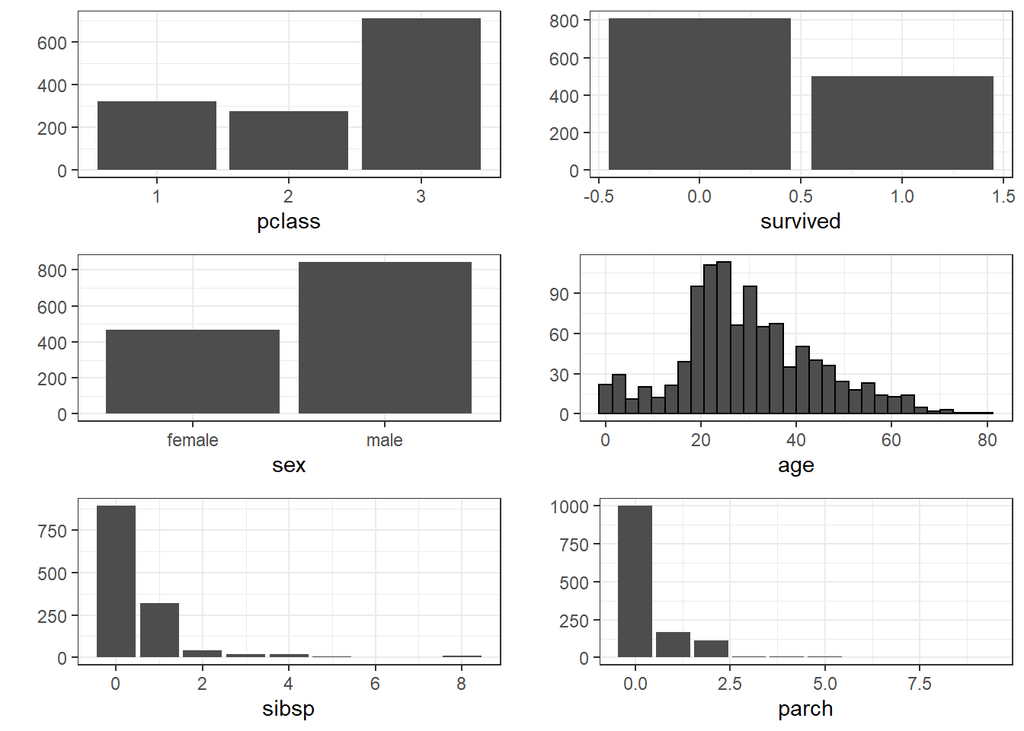

```r
tmp <- lapply(names(titanic),function(x) ggplot(data=titanic[,x,drop=FALSE])
              + aes_string(x)+xlab(x)+ylab("")) # base of ggplot
gb <- geom_bar(fill=gray(0.3)) # geom bar
gh <- geom_histogram(color="black",fill=gray(0.3),bins=30)
grid.arrange(tmp[[1]]+gb,tmp[[2]]+gb,tmp[[3]]+gb,
             tmp[[4]]+gh,tmp[[5]]+gb,tmp[[6]]+gb,ncol=2)
```

Before taking any action, lets also consider the *Spearman correlations*:

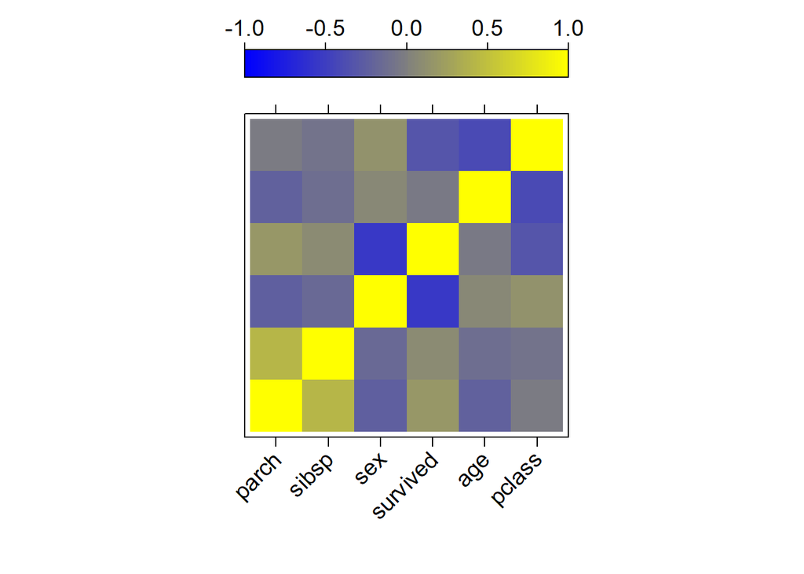

```r
cp <- cor(data.matrix(na.omit(titanic)),method="spearman")
ord <- rev(hclust(as.dist(1-abs(cp)))$order)
colPal <- colorRampPalette(c("blue","yellow"),space="rgb")(100)
levelplot(cp[ord,ord],
          xlab="",
          ylab="",
          col.regions=colPal,
          at=seq(-1,1,length.out=100),
          colorkey=list(space="top",labels=list(cex=1.2)),
          scales=list(x=list(rot=45),
                      y=list(draw=FALSE),
                      cex=1.2)
          )
```

In the correlation plot, we see a slight correlation between `survived` and `sex` (-0.54), as well as between `sibsp` and `parch` (0.42) and between `pclass` and `age` (-0.40). We have no reason to believe there is an issue of collinearity, such that any two variables encode the same information. Plausible explanations include that women (and kids) are assisted in getting off ship. And that elder people are more frequent in 1st class areas.

The last statement, can be further highlighted (or investigated) in the boxplot below. The slight negative correlation is ascribed to elder persons in 1st class.

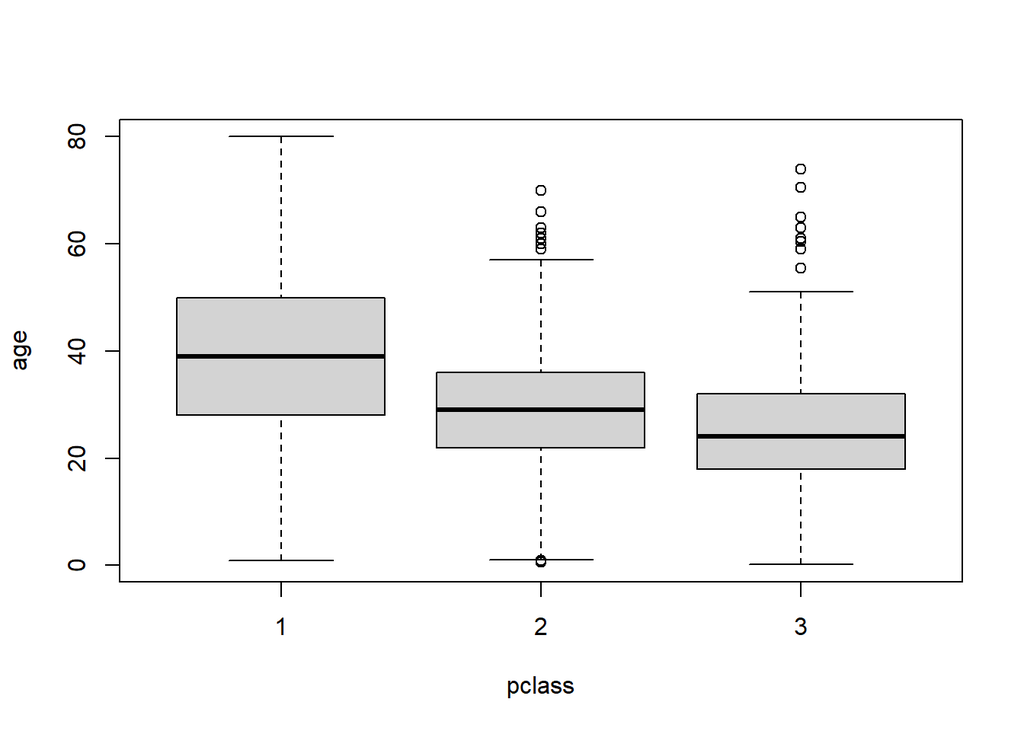

```r
boxplot(age~pclass,data=titanic) # check distribution of age wrt pclass
```

The barplots show that `sibsp` and `parch` are highly right skewed. As a predictor variable, this is unwanted. To remedy this, we alter the variables, such that both are binary. `sibsp` will be 0 if no siblings/spouses are aboard, 1 otherwise. `parch` will be 0 if parents/children are aboard, 0 otherwise.

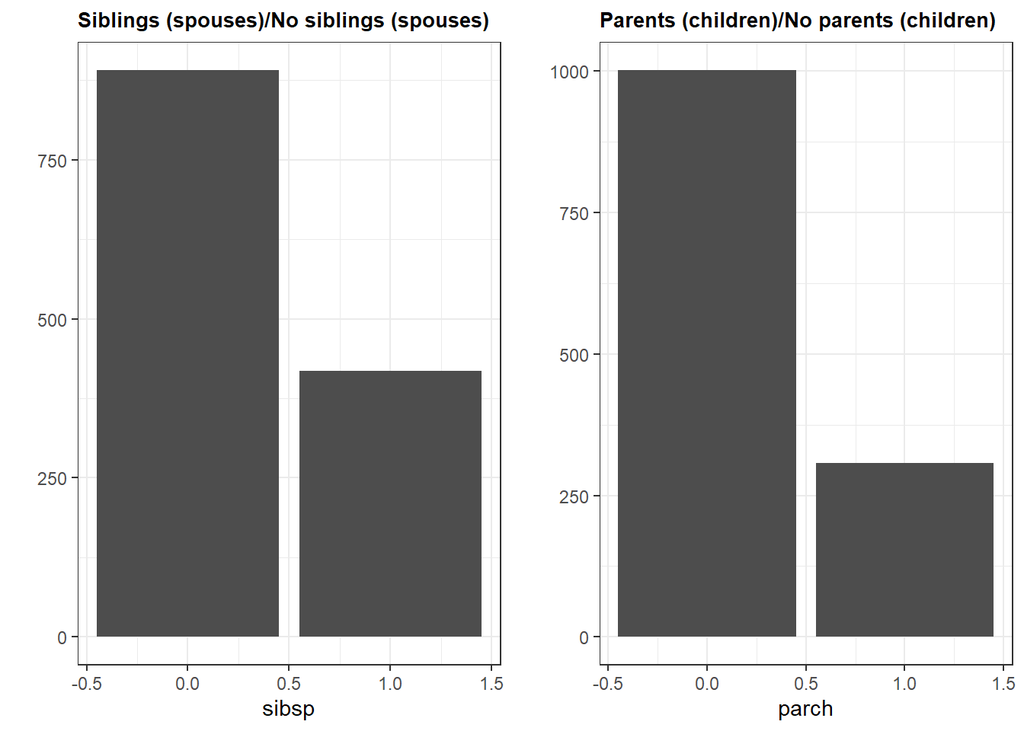

```r
#  transform
titanic <- transform(titanic,sibsp=ifelse(sibsp<1,0,1),parch=ifelse(parch<1,0,1))
p1 <- ggplot(titanic,aes(sibsp)) +
  geom_bar(fill=gray(0.3)) +
  ylab("") +
  ggtitle("Siblings (spouses)/No siblings (spouses)") +
  theme(plot.title = element_text(size = 10, face = "bold"))
p2 <- ggplot(titanic,aes(parch)) +
  geom_bar(fill=gray(0.3)) +
  ylab("") +
  ggtitle("Parents (children)/No parents (children)") +
  theme(plot.title = element_text(size = 10, face = "bold"))
grid.arrange(p1,p2,ncol=2)
```

Lets now investigate the correlation further between (transformed) `sibsp` and `parch` using a table:

```r
table(titanic$sibsp,titanic$parch,dnn=c('sibsp','parch')) # table
```

```
##      parch
## sibsp   0   1
##     0 790 101
##     1 212 206
```

Having siblings aboard is intuitively not a indicator that children/parents are also present, thus we would expect the sibling against parents/children to be uniformly distributed among the cells. In that case, we could loosely interpret the distribution of the table as the joint distribution of spouse and children/parents. If passenger $x$ has no spouse, it is expected that passenger $x$ has no children aboard either (but could have parents aboard). Thus it is expected that the (0,0) entry is high. If passenger $x$ has a spouse, it is more likely that they also has children (aboard). The ratio 212-206 against 790-101 reflects this intuitive distribution. This could explain the slight positive correlation between `sibsp` and `parch`. Following this logic, the variables are not strictly collinear, and we should embrace both in the model.

## Imputation

Now to handle the missing values, lets do a linear regression with age as response (excluding NA observations). Lets start by checking the effect of each variable on age

```r
titanicClean <- subset(titanic,is.na(titanic$age)==F) # exclude NA obs
form <- age~sex+survived+sibsp+parch+pclass # formula
lm0Age <- lm(age~1,data=titanicClean) # null model with intercept only
add1(lm0Age,form,test="F")
```

```
## Single term additions
##
## Model:
## age ~ 1
##          Df Sum of Sq    RSS    AIC  F value    Pr(>F)
## <none>                217097 5582.8
## sex       1       879 216218 5580.6   4.2461  0.039588 *
## survived  1       669 216428 5581.6   3.2271  0.072718 .
## sibsp     1      2149 214948 5574.4  10.4394  0.001272 **
## parch     1     12601 204496 5522.3  64.3331 2.805e-15 ***
## pclass    2     37339 179758 5389.4 108.3263 < 2.2e-16 ***
## ---
## Signif. codes:  0 '***' 0.001 '**' 0.01 '*' 0.05 '.' 0.1 ' ' 1
```

We already checked the pairwise associations (spearman correlation), and found no obvious reason to exclude any variables. In the output from `add1` above we see that all variables are (borderline) significant as single predictors of age.

Lets examine this more

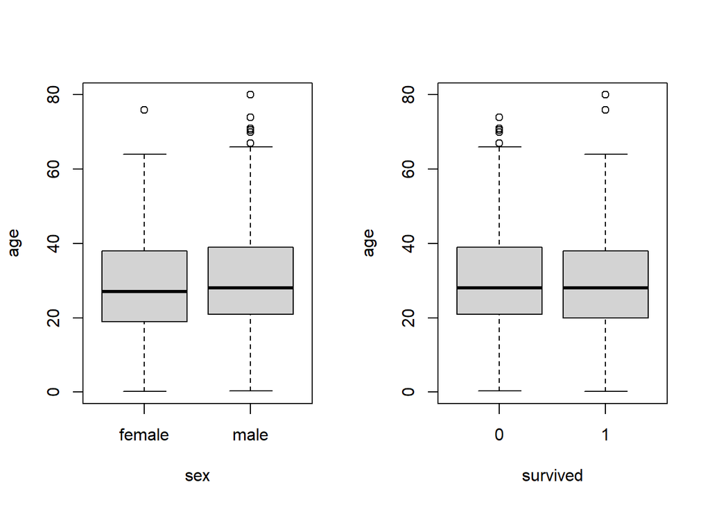

```r
par(mfrow=c(1,2))
boxplot(age~sex,data=titanicClean)
boxplot(age~survived,data=titanicClean)
```

From the above, it appears that the `age` distribution, given `sex`, is independent of `sex`. Same holds for the `age` distribution, given `survived`. From this realization, we would look at model, where we exclude these two variables.

What remains is `sibsp`, `parch` and `pclass`.

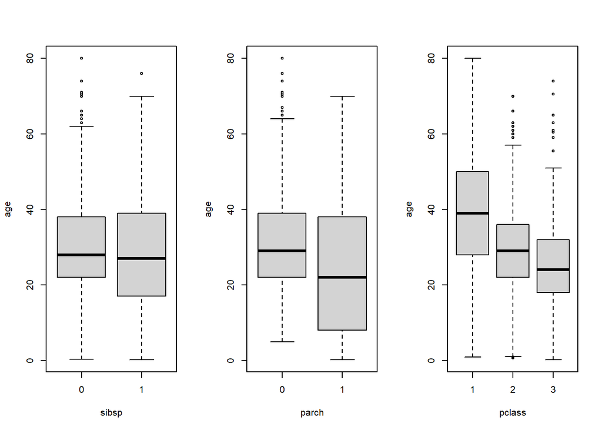

```r
par(mfrow=c(1,3))
boxplot(age~sibsp,data=titanicClean)
boxplot(age~parch,data=titanicClean)
boxplot(age~pclass,data=titanicClean)
```

From the boxplots, we cannot rule out the significance of these variables. Especially `pclass` seems to be a good predictor. Lets consider interactions:

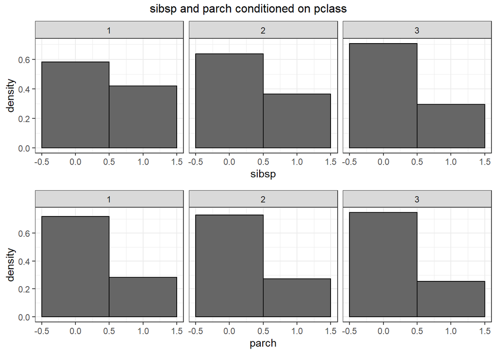

```r
# density histograms for each pclass, wrt sibsp and parch,
ip1<- ggplot(titanicClean,aes(sibsp))+geom_histogram(aes(y=..density..),color="black",fill=gray(0.4),bins=2)+facet_wrap(pclass~.)
ip2 <- ggplot(titanicClean,aes(parch))+geom_histogram(aes(y=..density..),color="black",fill=gray(0.4),bins=2)+facet_wrap(pclass~.)
grid.arrange(ip1,ip2,top="sibsp and parch conditioned on pclass")
```

From the above plots (where we have normalized the barplot), we see that there are no apparent interaction between `parch` and `pclass`, however it is plausible that there is in fact some (minor) interaction between `pclass` and `sibsp`.

In conclusion, we will consider a linear model where `age` depends on `pclass` and `sibsp` (including interaction term) and additively on `parch`:

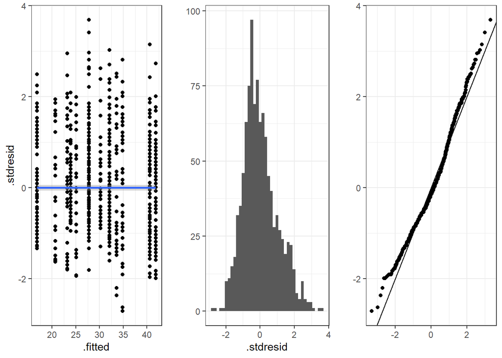

```r
lmAge <-lm(age~sibsp*pclass+parch, data=titanicClean) # fit our candidate model
data_diag1 <- fortify(lmAge)
grid.arrange(
  qplot(.fitted, .stdresid, data = data_diag1) + geom_smooth(),
qplot(.stdresid, data = data_diag1, bins = I(40)),
qplot(sample = .stdresid, data = data_diag1, geom = "qq") + geom_abline(),
ncol = 3
)
```

We seem to have captured the mean value structure (A1). The homogeneity seems okay (A2), and the residuals are approximately normal (A3), though a little right skewed. We accept our model, and impute our missing values:

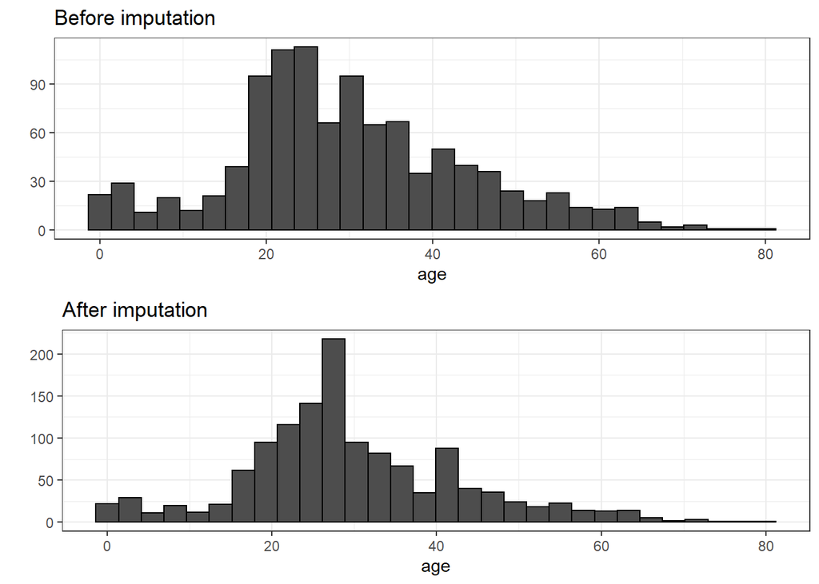

```r
naPart <-titanic[is.na(titanic$age),] # get NA obs
naPart$age <- NULL # remove age column
imputeAge <- predict(lmAge,data.frame(naPart)) # impute (predicted values of age)
titanic[is.na(titanic$age),]$age <- imputeAge # replace NA values with predictions

# plot before/after
q2 <-ggplot(titanic,aes(age)) +
  geom_histogram(color="black",fill=gray(0.3),bins=30) +
  ylab("")+
  ggtitle("After imputation")
q1 <- ggplot(titanicClean,aes(age)) +
  geom_histogram(color="black",fill=gray(0.3),bins=30) +
  ylab("")+
  ggtitle("Before imputation")
grid.arrange(q1,q2,nrow=2)
```

This ends the explatory analysis and data preperation. We will now continue to the analysis

# Analysis

In the imputation analysis above, we already explored some interactions. Since `age` now enters as a possible predictor of `survived`, we should also look into possible interactions between `age` and other variables. In the previous boxplots of `age` against the other variables, there is not strong evidence that is any interaction present. In order to not overfit out model (and maintain some variability), we will exclude the possiblity of interactions between `age` and any other variable.

Should we even include age? The plot below doesn’t indicate that we should.

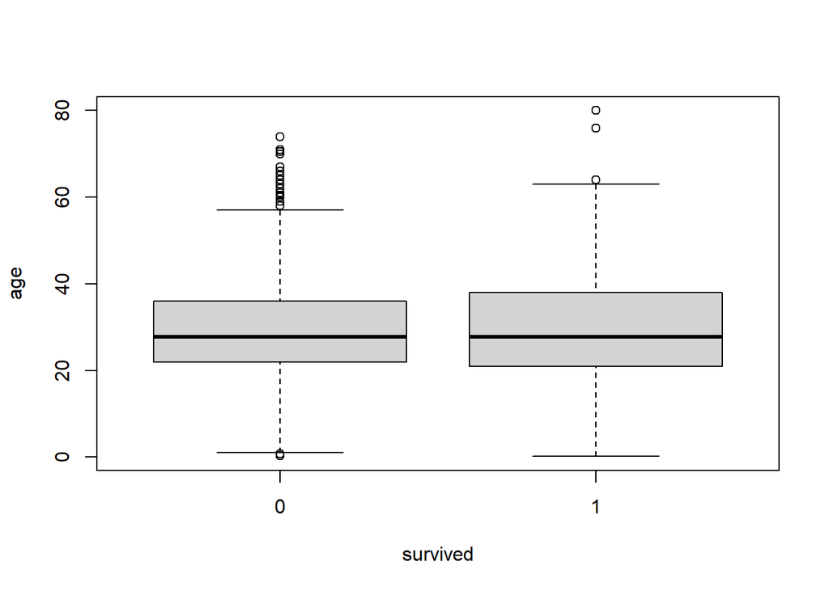

```r
boxplot(age~survived,data=titanic)
```

It is not obvious that the age distribution differ between groups, hence as a predictor of `survived`, `age` might not be appropriate. The same conclusion can be drawn from a marginal association test:

```r
# marginal association test
form <- survived ~ age + sibsp + parch + pclass + sex
glmSurvived0 <-glm(survived~1,family=binomial(link=logit),data=titanic)
add1(glmSurvived0,form, test="LRT")
```

```
## Single term additions
##
## Model:
## survived ~ 1
##        Df Deviance    AIC    LRT  Pr(>Chi)
## <none>      1741.0 1743.0
## age     1   1739.9 1743.9   1.17 0.2798670
## sibsp   1   1726.5 1730.5  14.48 0.0001419 ***
## parch   1   1702.5 1706.5  38.54 5.363e-10 ***
## pclass  2   1613.3 1619.3 127.77 < 2.2e-16 ***
## sex     1   1368.1 1372.1 372.92 < 2.2e-16 ***
## ---
## Signif. codes:  0 '***' 0.001 '**' 0.01 '*' 0.05 '.' 0.1 ' ' 1
```

As single predictors, the other variables are however highly significant. Lets also explore this with so called ‘mosaic plots’:

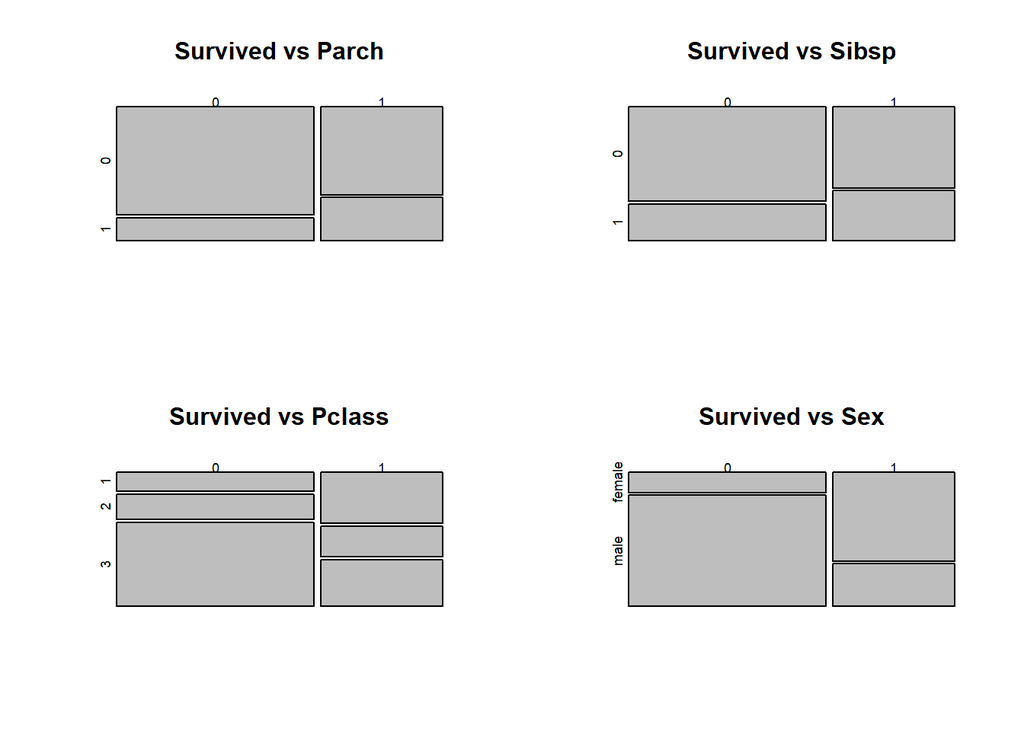

```r
t1 <- table(titanic$survived,titanic$parch)
t2 <- table(titanic$survived,titanic$sibsp)
t3 <- table(titanic$survived,titanic$pclass)
t4 <- table(titanic$survived,titanic$sex)
par(mfrow=c(2,2))
plot(t1,main="Survived vs Parch")
plot(t2,main="Survived vs Sibsp")
plot(t3,main="Survived vs Pclass")
plot(t4,main="Survived vs Sex")
```

From the mosaic plots above, we see a clear shift in distribution within all (other) variables across the survival binary reponse. This strengthens our belief that these four variables has some predictive power in relation to `survived` passengers. The `sibsp` variable is not as strong as the others, which was also the conclusion from the `add1` summary. We already investigated potential collinearity among the variables in the imputation section, and excluded any strong collinearities. We did however find some potential interaction between `sibsp` and `pclass`. In conclusion, our candidate final model will contain `sex`,`parch`, `sibsp` and `pclass` aswell as interaction between the latter. Lets fit it:

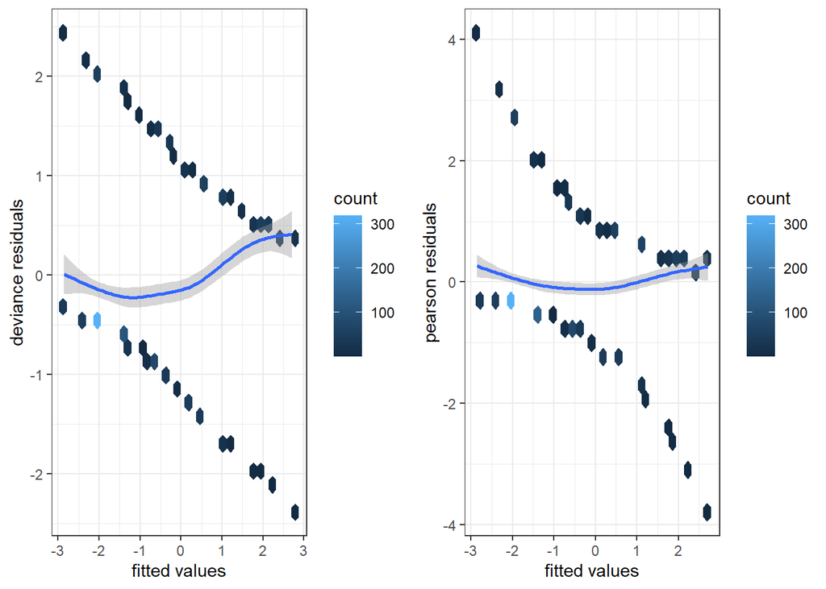

```r
glmSurvived <- glm(survived~sex+parch+sibsp*pclass,family=binomial(link=logit),data=titanic)

survivedDiag <- transform(titanic,
                          .fitted = predict(glmSurvived),
                          .deviance = residuals(glmSurvived),
                          .pearson = residuals(glmSurvived,
                          type="pearson")
                          )

p1<-qplot(.fitted,.deviance,data=survivedDiag,geom="hex")+geom_smooth(size=1)+xlab("fitted values")+ylab("deviance residuals")
p2 <- qplot(.fitted,.pearson,data=survivedDiag,geom="hex")+geom_smooth(size=1)+xlab("fitted values")+ylab("pearson residuals")
grid.arrange(p1,p2,ncol=2)
```

## Model validation

To verify that our model fits, or if there exists some misspecification, we will let us inspire by Exercise 3, of exam 2018.

Hence we will do a bootsrap study, and simulate $B=1000$ new instances of `survived` based on our logistic regression model. Since we have 5 covariates (three sets on 2 levels, one on 3 levels, and one on 4 levels), we would have to compare the reponse `survived` of our `titanic` dataset with $2^3*3*4 = 96$ histograms to capture all combination of the covariates.

Rather than making a visual interpretation, we will compute the a 95% interval for each of the 96 combinations of covariates, and if the observed frequency of survivors relative to this particular combination of covariates is within the range we will add $+1$ to a counter $C$. Then $C / 96$ will be a measure of how many histograms contain the observed frequency of the response.

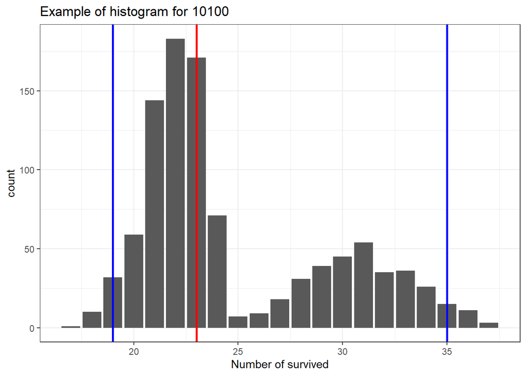

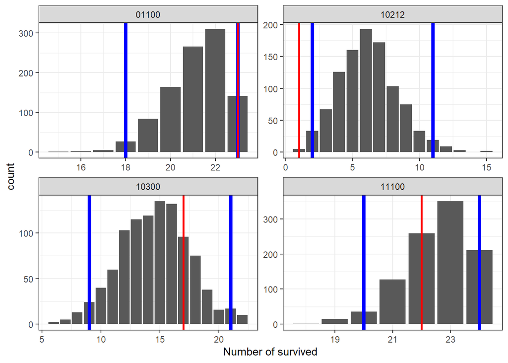

Above we see some example histograms. The red lines is the observed response (number of survivors) and the blue lines span the 95% confidence interval. The code for each plot has the meaning: `sibsp`-`parch`-`pclass`-`sex`-`pclasssibsp`.

```r
# check how many simulated histograms contain the model response of original data
l <- rep(0,96) # initiate

for(i in 0:95){
  # get range of sim data for particular covariate combination
  qts<-quantile(NewData[I(B*i+1):I(B*(i+1)),]$Ycount,c(0.025,0.975))
  # check if response is within decision boundary of 95%
  l[i+1] <- ifelse(titanicCount[i+1,1] >= qts[1] & titanicCount[i+1,1] <= qts[2],1,0)
}

# probability that response is captured by our model for a given combination of covariates
sum(l)/96
```

```
## [1] 0.9270833
```

This number tells us that for more than 90% of our histograms, the observed values is contained in a 95% confidence interval. On the basis hereof, we would accept that our model is in fact a good prediction model of passenger survival.

# Reporting the model

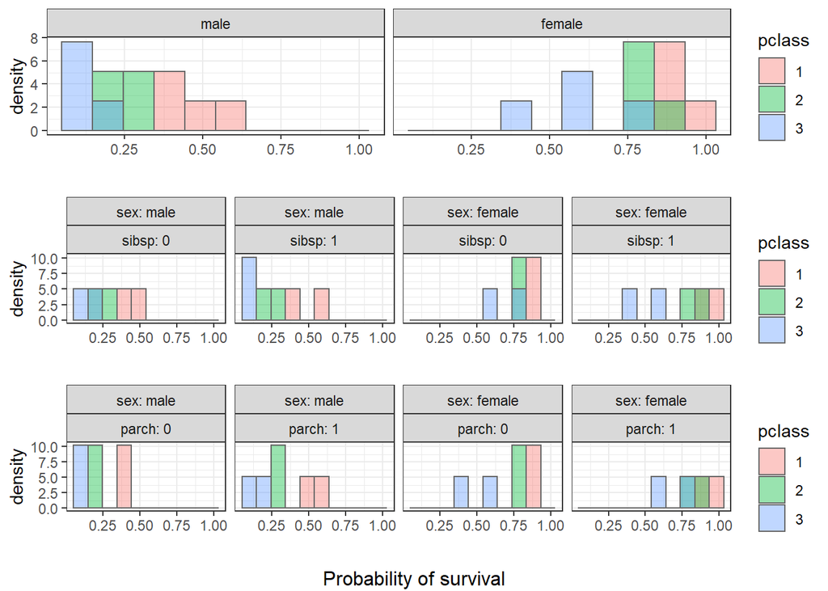

```r
# prediction frame (all combinations of below)
predFrame <- expand.grid(
  sibsp=c(0,1),
  parch=c(0,1),
  pclass=factor(c(1,2,3)),
  sex=c("male","female")
)
# if type != response, predictions are of log-odds, thus probabilities on the logit-scale
predSurvived <- predict(glmSurvived,newdata=predFrame,se.fit=T,type="response")
predFrame <- cbind(predFrame,as.data.frame(predSurvived))

p3<-ggplot(predFrame, aes(x=fit, fill=pclass)) +
    geom_histogram(aes(y=..density..),position="identity", colour="grey40", alpha=0.4, bins = 10) +
    facet_grid(. ~ sex) +
  xlab("")
p4 <-ggplot(predFrame, aes(x=fit, fill=pclass)) +
    geom_histogram(aes(y=..density..),position="identity", colour="grey40", alpha=0.4, bins = 10) +
    facet_grid(. ~ sex+sibsp,label=label_both) +
  xlab("")
p5 <- ggplot(predFrame, aes(x=fit, fill=pclass)) +
    geom_histogram(aes(y=..density..),position="identity", colour="grey40", alpha=0.4, bins = 10) +
    facet_grid(. ~ sex+parch,label=label_both) +
  xlab("")
grid.arrange(p3,p4,p5,ncol=1,bottom="Probability of survival")
```

From the barplots above, we can tell that our model predicts the highest probability of survival if you are female. We also see that being a higher class passenger increases your chance of survival (regardless of sex). This effect is most visible between 3rd and 2nd class for females, while more incremental for males between the three passenger classes.

Having siblings or spouses aboard seems to offer a slight increase of survival for 2nd and 1st class females. But the picture is vague.

When it comes to children or parents, we see a slight increase of survival for both males and females. If you have a parent aboard, you are intuitively young, and it is likely that younger people were assisted more in getting off ship. On the other hand, if you are a parent, especially female, you might also be prioritized. In a revised model, it might have made sense to organize age into young, middle-age and old, to investigate this effect.

The most dominant effect that our model shows is the high effect on survival given that you are female or a 1st class passenger. Or you could also say, being male or 3rd class passenger are good predictors of low chance of survival.